# Descripción del dataset

Este dataset concierne a las redes de metro globales. Se estudia los kilómetros, paradas, el uso, año de construcción y de última ampliación así como aspectos relacionados con la ciudad donde se encuentra: población, localización geográfica, país.

Tras limpiar estos datos se analizan aspectos como el número de viajes por habitante, latitudes con alta densidad de uso (este asiático), ciudades con mas estaciones, etc.

Las bases de datos originales están localizables en:

- del metro https://www.kaggle.com/datasets/drahulsingh/metro-systems-worldwide
- de ciudades https://simplemaps.com/data/world-cities

# Integración y selección de los datos de interés a analizar

```python
import numpy as np
import pandas as pd
from itertools import chain

import matplotlib.pyplot as plt
from matplotlib import ticker

plt.style.use('seaborn-v0_8-whitegrid')
import seaborn as sns

import warnings
import copy
```

## Carga de bases de datos

Cargamos dataset del metro (de https://www.kaggle.com/datasets/drahulsingh/metro-systems-worldwide).

```python
df_metro = pd.read_csv("../dataset/Metro-Systems-Worldwide.csv")
```

```python
df_metro.rename(columns={'Country\r\nregion': 'Country',
                   'Service\r\nopened': 'Year opened',
                   'Last\r\nexpanded': 'Last year expanded',
                   'Annual ridership\r\n(millions)': 'Annual ridership (millions)'
                  }, inplace=True)
```

```python
df_metro.head()
```

|  | City | Country | Name | Year opened | Last year expanded | Stations | System length | Annual ridership (millions) |
| --- | --- | --- | --- | --- | --- | --- | --- | --- |
| 0 | Algiers | Algeria | Algiers Metro | 2011 | 2018 | 19 | 18.5 km (11.5 mi) | 45.3 (2019) |
| 1 | Buenos Aires | Argentina | Buenos Aires Underground | 1913 | 2019 | 78 | 56.7 km (35.2 mi) | 74.0 (2020) |
| 2 | Yerevan | Armenia | Yerevan Metro | 1981 | 1996 | 10 | 12.1 km (7.5 mi) | 23.3 (2022) |
| 3 | Sydney | Australia | Sydney Metro | 2019 | – | 13 | 36 km (22 mi) | 16.3 (2022) |
| 4 | Vienna | Austria | Vienna U-Bahn | 1978 | 2017 | 98 | 83.3 km (51.8 mi) | 459.8 (2019) |

Cargamos dataset de ciudades (de https://simplemaps.com/data/world-cities):

```python
df_cities = pd.read_csv("../dataset/worldcities.csv")
df_cities = df_cities[["city_ascii","country","admin_name","population","lat","lng"]]
df_cities.head()
```

|  | city_ascii | country | admin_name | population | lat | lng |
| --- | --- | --- | --- | --- | --- | --- |
| 0 | Tokyo | Japan | Tōkyō | 37732000.0 | 35.6897 | 139.6922 |
| 1 | Jakarta | Indonesia | Jakarta | 33756000.0 | -6.1750 | 106.8275 |
| 2 | Delhi | India | Delhi | 32226000.0 | 28.6100 | 77.2300 |
| 3 | Guangzhou | China | Guangdong | 26940000.0 | 23.1300 | 113.2600 |
| 4 | Mumbai | India | Mahārāshtra | 24973000.0 | 19.0761 | 72.8775 |

## Combinar ambos datasets

### Campos del merge

Pero hay ciudades homónimas en muchos países (en ambos dataframes):

```python
df_cities["city_ascii"].value_counts(), df_metro["City"].value_counts()
```

```
(Santa Cruz      17
 San Fernando    16
 Santa Ana       15
 Santa Maria     14
 San Juan        14
                 ..
 Arsenyev         1
 Panjakent        1
 Kleve            1
 Venkatagiri      1
 Nordvik          1
 Name: city_ascii, Length: 41140, dtype: int64,
 Seoul            3
 Tokyo            3
 New York City    3
 London           2
 Manila           2
                 ..
 Medellín         1
 Prague           1
 Copenhagen       1
 Santo Domingo    1
 Hanoi            1
 Name: City, Length: 194, dtype: int64)
```

Incluso mas complicado, hay ciudades repetidas en dataset del metro:

```python
unique_cities_metro = df_metro.groupby(['City', 'Country']).agg({'Name': lambda x: x.index.tolist()}).reset_index()
unique_cities_metro.rename(columns={'Name': 'Original indexes'}, inplace=True)
unique_cities_metro['Count'] = [len(k) for k in unique_cities_metro['Original indexes']]
mask_cities_metro = unique_cities_metro['Count']>1
unique_cities_metro[mask_cities_metro]
```

|  | City | Country | Original indexes | Count |
| --- | --- | --- | --- | --- |
| 11 | Bangkok | Thailand | [173, 174] | 2 |
| 94 | London | United Kingdom | [185, 186] | 2 |
| 100 | Manila | Philippines | [150, 151] | 2 |
| 120 | New York City | United States | [194, 195, 196] | 3 |
| 130 | Philadelphia | United States | [197, 198] | 2 |
| 151 | Seoul | South Korea | [136, 137, 138] | 3 |
| 174 | Tokyo | Japan | [124, 125, 126] | 3 |
| 190 | Yokohama | Japan | [127, 128] | 2 |

```python
# repeated cities vs sum
unique_cities_metro[mask_cities_metro]['Count'].shape[0] , \
unique_cities_metro[mask_cities_metro]['Count'].sum()
```

```
(8, 19)
```

Comprobamos que se debe que en una misma ciudad-país puede haber varios sistemas de metro:

```python
indexes = list(chain.from_iterable(unique_cities_metro[mask_cities_metro]['Original indexes']))
df_metro.iloc[indexes ,:]
```

|  | City | Country | Name | Year opened | Last year expanded | Stations | System length | Annual ridership (millions) |
| --- | --- | --- | --- | --- | --- | --- | --- | --- |
| 173 | Bangkok | Thailand | BTS Skytrain | 1999 | 2021 | 60 | 68.2 km (42.4 mi) | 236.9 (2020) |
| 174 | Bangkok | Thailand | Metropolitan Rapid Transit | 2004 | 2019 | 53 | 71 km (44 mi) | 95.3 (2020) |
| 185 | London | United Kingdom | London Underground | 1863 | 2021 | 272 | 402 km (250 mi) | 1,026 (2022) |
| 186 | London | United Kingdom | Docklands Light Railway | 1987 | 2011 | 45 | 34 km (21 mi) | 39.9 (2020) |
| 150 | Manila | Philippines | Manila Light Rail Transit System | 1984 | 2021 | 33 | 37.2 km (23.1 mi) | 218.2 (2019) |
| 151 | Manila | Philippines | Manila Metro Rail Transit System | 1999 | 2000 | 13 | 16.9 km (10.5 mi) | 96.9 (2019) |
| 194 | New York City | United States | New York City Subway | 1904 | 2017 | 424 | 399 km (248 mi) | 1,793.1 (2022) |
| 195 | New York City | United States | Staten Island Railway | 1925 | 2017 | 21 | 22.5 km (14.0 mi) | 3.8 (2022) |
| 196 | New York City | United States | PATH | 1908 | 1937 | 13 | 22.2 km (13.8 mi) | 45.5 (2022) |
| 197 | Philadelphia | United States | SEPTA | 1907 | 1973 | 72 | 59.1 km (36.7 mi) | 41.2 (2022) |
| 198 | Philadelphia | United States | PATCO Speedline | 1936 | 1980 | 13 | 22.9 km (14.2 mi) | 4.9 (2022) |
| 136 | Seoul | South Korea | Seoul Metropolitan Subway | 1974 | 2022 | 279 | 345.3 km (214.6 mi) | 2,127.2 (2020) |
| 137 | Seoul | South Korea | Korail metro lines | 1994 | 2022 | 86 | 151.7 km (94.3 mi) | 426.4 (2019) |
| 138 | Seoul | South Korea | Shinbundang Line (Neo Trans) | 2011 | 2022 | 16 | 33.4 km (20.8 mi) | 122.5 (2019) |
| 124 | Tokyo | Japan | Toei Subway | 1960 | 2002 | 99 | 109.0 km (67.7 mi) | 1,174.9 (2019) |
| 125 | Tokyo | Japan | Tokyo Metro | 1927 | 2020 | 142 | 195.1 km (121.2 mi) | 2,757.4 (2019) |
| 126 | Tokyo | Japan | Rinkai Line | 1996 | 2002 | 8 | 12.2 km (7.6 mi) | 95.0 (2019) |
| 127 | Yokohama | Japan | Yokohama Municipal Subway | 1972 | 2008 | 40 | 53.4 km (33.2 mi) | 243.2 (2019) |
| 128 | Yokohama | Japan | Minatomirai Line | 2004 | 2008 | 6 | 4.1 km (2.5 mi) | 80.6 (2019) |

Por suerte no hay la triple combinanción ciudad-país-nombre del metro. Así tras hacer el merge no hemos de eliminar la columna `Name`.

```python
unique_cities_metro_name = df_metro.groupby(['City', 'Country','Name']).size().reset_index(name='Count')
mask = unique_cities_metro_name['Count']>1
unique_cities_metro_name[mask]
```

|  | City | Country | Name | Count |
| --- | --- | --- | --- | --- |

Por otro lado, también hay varias ciudades hómonimas en mismo país:

```python
unique_cities_cities = df_cities.groupby(['city_ascii', 'country']).size().reset_index(name='Count')
mask_cities_cities = unique_cities_cities['Count']>1
unique_cities_cities[mask_cities_cities]
```

|  | city_ascii | country | Count |
| --- | --- | --- | --- |
| 55 | Abasolo | Mexico | 2 |
| 56 | Abay | Kazakhstan | 2 |
| 80 | Aberdeen | United States | 4 |
| 97 | Abington | United States | 2 |
| 169 | Acatlan | Mexico | 2 |
| ... | ... | ... | ... |
| 42236 | Zhangjiazhuang | China | 2 |
| 42239 | Zhangping | China | 2 |
| 42262 | Zheleznogorsk | Russia | 2 |
| 42282 | Zhijiang | China | 2 |
| 42301 | Zhongshan | China | 2 |

1452 rows × 3 columns

Pero de todas esas, solo nos competen las que tienen metro:

```python
pd.merge(unique_cities_metro, unique_cities_cities[mask_cities_cities],
              left_on=["City","Country"],
              right_on=["city_ascii","country"])[['City','Country','Count_y']]
```

|  | City | Country | Count_y |
| --- | --- | --- | --- |
| 0 | Changsha | China | 2 |
| 1 | Cleveland | United States | 3 |
| 2 | Dongguan | China | 2 |
| 3 | Fuzhou | China | 2 |
| 4 | Gwangju | South Korea | 2 |
| 5 | Jaipur | India | 2 |
| 6 | Miami | United States | 2 |
| 7 | Suzhou | China | 2 |
| 8 | Taizhou | China | 2 |
| 9 | Wuxi | China | 2 |

Vamos a suponer en cada conflicto que la ciudad con metro será la de mayor población. Es decir, vuelvo a guardar como ya hice en `unique_cities_metro` los índices del dataset original. Vuelvo a mergear. Y en cada registro (conflicto) guardo índices de ciudades mas pequeñas. Las que finalmente elimino del dataset de ciudades.

```python
unique_cities_cities = df_cities.groupby(['city_ascii', 'country']).agg({'lat': lambda x: x.index.tolist()}).reset_index()
unique_cities_cities.rename(columns={'lat': 'Original indexes'}, inplace=True)
unique_cities_cities['Count'] = [len(k) for k in unique_cities_cities['Original indexes']]
mask_cities_cities = unique_cities_cities['Count']>1
unique_cities_cities[mask_cities_cities]
```

|  | city_ascii | country | Original indexes | Count |
| --- | --- | --- | --- | --- |
| 55 | Abasolo | Mexico | [7800, 36261] | 2 |
| 56 | Abay | Kazakhstan | [22412, 38952] | 2 |
| 80 | Aberdeen | United States | [20999, 26822, 29107, 29794] | 4 |
| 97 | Abington | United States | [14521, 28967] | 2 |
| 169 | Acatlan | Mexico | [22509, 24113] | 2 |
| ... | ... | ... | ... | ... |
| 42236 | Zhangjiazhuang | China | [15064, 25281] | 2 |
| 42239 | Zhangping | China | [2782, 44147] | 2 |
| 42262 | Zheleznogorsk | Russia | [5920, 12556] | 2 |
| 42282 | Zhijiang | China | [1574, 5287] | 2 |
| 42301 | Zhongshan | China | [275, 21491] | 2 |

1452 rows × 4 columns

```python
df_merge = pd.merge(unique_cities_metro, unique_cities_cities[mask_cities_cities],
              left_on=["City","Country"],
              right_on=["city_ascii","country"])
df_merge[['City','Country','Count_y','Original indexes_y']]
```

|  | City | Country | Count_y | Original indexes_y |
| --- | --- | --- | --- | --- |
| 0 | Changsha | China | 2 | [151, 1165] |
| 1 | Cleveland | United States | 3 | [474, 13250, 37437] |
| 2 | Dongguan | China | 2 | [38, 12924] |
| 3 | Fuzhou | China | 2 | [186, 207] |
| 4 | Gwangju | South Korea | 2 | [527, 2273] |
| 5 | Jaipur | India | 2 | [254, 38513] |
| 6 | Miami | United States | 2 | [100, 34184] |
| 7 | Suzhou | China | 2 | [125, 172] |
| 8 | Taizhou | China | 2 | [135, 383] |
| 9 | Wuxi | China | 2 | [241, 1026] |

```python
df_merge.shape[0] , df_merge[['Count_y']].sum().values[0] # cities unique vs cities total
```

```
(10, 21)
```

```python
indexes = list(chain.from_iterable(df_merge['Original indexes_y']))
df_cities.iloc[indexes ,:][['country','city_ascii','population']]
```

|  | country | city_ascii | population |
| --- | --- | --- | --- |
| 151 | China | Changsha | 4766296.0 |
| 1165 | China | Changsha | 717700.0 |
| 474 | United States | Cleveland | 1683059.0 |
| 13250 | United States | Cleveland | 72589.0 |
| 37437 | United States | Cleveland | 11285.0 |
| 38 | China | Dongguan | 10646000.0 |
| 12924 | China | Dongguan | 75135.0 |
| 186 | China | Fuzhou | 4047200.0 |
| 207 | China | Fuzhou | 3671192.0 |
| 527 | South Korea | Gwangju | 1490092.0 |
| 2273 | South Korea | Gwangju | 310278.0 |
| 254 | India | Jaipur | 3073350.0 |
| 38513 | India | Jaipur | 10259.0 |
| 100 | United States | Miami | 5711945.0 |
| 34184 | United States | Miami | 12997.0 |
| 125 | China | Suzhou | 5352924.0 |
| 172 | China | Suzhou | 4330000.0 |
| 135 | China | Taizhou | 5031000.0 |
| 383 | China | Taizhou | 2162461.0 |
| 241 | China | Wuxi | 3245179.0 |
| 1026 | China | Wuxi | 853197.0 |

```python
indexes_to_remove = list()
for indexes in df_merge['Original indexes_y']:
    result_dict = dict(df_cities.loc[indexes, 'population'])
    max_value = max(result_dict.values())
    indexes_with_smaller_values = [key for key, value in result_dict.items() if value < max_value]
    indexes_to_remove.append(indexes_with_smaller_values)
indexes_to_remove = list(chain.from_iterable(indexes_to_remove))
```

```python
len(indexes_to_remove) # cities to remove
```

```
11
```

```python
df_cities.shape
```

```
(44691, 6)
```

```python
df_cities.drop(indexes_to_remove, axis=0, inplace=True)
```

```python
df_cities.shape
```

```
(44680, 6)
```

```python
# comprobación
unique_cities_cities = df_cities.groupby(['city_ascii', 'country']).size().reset_index(name='Count')
mask_cities_cities = unique_cities_cities['Count']>1
pd.merge(unique_cities_metro, unique_cities_cities[mask_cities_cities],
              left_on=["City","Country"],
              right_on=["city_ascii","country"])
```

|  | City | Country | Original indexes | Count_x | city_ascii | country | Count_y |
| --- | --- | --- | --- | --- | --- | --- | --- |

### pd.merge()

```python
df = pd.merge(df_metro, df_cities,
              left_on=["City","Country"],
              right_on=["city_ascii","country"],
              how='left').drop('city_ascii', axis=1)
df.drop('Country', axis=1, inplace=True)
```

```python
df.head()
```

|  | City | Name | Year opened | Last year expanded | Stations | System length | Annual ridership (millions) | country | admin_name | population | lat | lng |
| --- | --- | --- | --- | --- | --- | --- | --- | --- | --- | --- | --- | --- |
| 0 | Algiers | Algiers Metro | 2011 | 2018 | 19 | 18.5 km (11.5 mi) | 45.3 (2019) | Algeria | Alger | 3415811.0 | 36.7539 | 3.0589 |
| 1 | Buenos Aires | Buenos Aires Underground | 1913 | 2019 | 78 | 56.7 km (35.2 mi) | 74.0 (2020) | Argentina | Buenos Aires, Ciudad Autónoma de | 16710000.0 | -34.5997 | -58.3819 |
| 2 | Yerevan | Yerevan Metro | 1981 | 1996 | 10 | 12.1 km (7.5 mi) | 23.3 (2022) | Armenia | Yerevan | 1075800.0 | 40.1814 | 44.5144 |
| 3 | Sydney | Sydney Metro | 2019 | – | 13 | 36 km (22 mi) | 16.3 (2022) | Australia | New South Wales | 4840600.0 | -33.8678 | 151.2100 |
| 4 | Vienna | Vienna U-Bahn | 1978 | 2017 | 98 | 83.3 km (51.8 mi) | 459.8 (2019) | Austria | Wien | 1973403.0 | 48.2083 | 16.3725 |

Comprobamos que las 205 ciudades con metros se corresponden 1 a 1 en el dataframe mergeado:

```python
[k.shape[0] for k in [df_metro,df]]
```

```
[205, 205]
```

# Limpieza de los datos

Estudiamos NaN

```python
def df_check_nan_null(df):
    print('** NA **')
    # note: read your csv with empty cells interpreted as empty strings by simply setting keep_default_na=False
    na_cols = df.isnull().sum()
    print("\nNon NaN cols:\n", na_cols[na_cols != 0])

    print('\n\n** Blancos **')
    blank_cols = (df == "").sum()
    blank_cols = blank_cols[blank_cols != 0]
    print("\nNon zero cols:\n", blank_cols)

    return na_cols, blank_cols
```

```python
na_cols, blank_cols = df_check_nan_null(df);
```

```
** NA **

Non NaN cols:
 Annual ridership (millions)    16
country                        17
admin_name                     19
population                     17
lat                            17
lng                            17
dtype: int64


** Blancos **

Non zero cols:
 Series([], dtype: int64)
```

16 registros del dataset del metro no recogen los millones de pasajeros.

## Mergeo sin ASCII

Los otros campos con 17 registros muy probablemente se deban a un incorrecto mergeado:

```python
def df_check_nan(df, na_cols, col_index=[1]): #[0,1]
    for k in col_index:
        col = na_cols[na_cols>0].index[k]
        print(col)
        mask = df[[col]].isnull().values
        index = df[mask].index
        display(df[mask].reset_index())
    return mask, index;
mask_nan, index_nan_merged_df = df_check_nan(df, na_cols);
```

```
country
```

|  | index | City | Name | Year opened | Last year expanded | Stations | System length | Annual ridership (millions) | country | admin_name | population | lat | lng |
| --- | --- | --- | --- | --- | --- | --- | --- | --- | --- | --- | --- | --- | --- |
| 0 | 10 | Brasília | Federal District Metro | 2001 | 2020 | 27 | 42.38 km (26.33 mi) | 42.8 (2019) | NaN | NaN | NaN | NaN | NaN |
| 1 | 16 | São Paulo | São Paulo Metro | 1974 | 2021 | 89 | 104.4 km (64.9 mi) | 1,104.149 (2022) | NaN | NaN | NaN | NaN | NaN |
| 2 | 38 | Hong Kong | Mass Transit Railway | 1979 | 2022 | 99 | 209.0 km (129.9 mi) | 1,616.30 (2021) | NaN | NaN | NaN | NaN | NaN |
| 3 | 59 | Ürümqi | Ürümqi Metro | 2018 | 2019 | 21 | 27.615 km (17.159 mi) | 19.11 (2020) | NaN | NaN | NaN | NaN | NaN |
| 4 | 65 | Xuzhou | Xuzhou Metro | 2019 | 2021 | 51 | 64.35 km (39.99 mi) | 20.94 (2020) | NaN | NaN | NaN | NaN | NaN |
| 5 | 67 | Medellín | Medellín Metro | 1995 | 2012 | 27 | 31.3 km (19.4 mi) | 215.2 (2022) | NaN | NaN | NaN | NaN | NaN |
| 6 | 68 | Prague | Prague Metro | 1974 | 2015 | 58 | 65.4 km (40.6 mi) | 251.4 (2020) | NaN | NaN | NaN | NaN | NaN |
| 7 | 94 | Kanpur | Kanpur Metro | 2021 | – | 9 | 8.98 km (5.58 mi) | NaN | NaN | NaN | NaN | NaN | NaN |
| 8 | 103 | Isfahan | Isfahan Urban Railway | 2015 | 2018 | 20 | 20.2 km (12.6 mi) | NaN | NaN | NaN | NaN | NaN | NaN |
| 9 | 158 | Nizhny Novgorod | Nizhny Novgorod Metro | 1985 | 2018 | 15 | 21.82 km (13.56 mi) | 29.9 (2022) | NaN | NaN | NaN | NaN | NaN |
| 10 | 172 | Taoyuan | Taoyuan Metro | 2017 | – | 22 | 53.1 km (33.0 mi) | 28.0 (2019) | NaN | NaN | NaN | NaN | NaN |
| 11 | 179 | İzmir | İzmir Metro | 2000 | 2014 | 17 | 20 km (12 mi) | 100 (2019) | NaN | NaN | NaN | NaN | NaN |
| 12 | 194 | New York City | New York City Subway | 1904 | 2017 | 424 | 399 km (248 mi) | 1,793.1 (2022) | NaN | NaN | NaN | NaN | NaN |
| 13 | 195 | New York City | Staten Island Railway | 1925 | 2017 | 21 | 22.5 km (14.0 mi) | 3.8 (2022) | NaN | NaN | NaN | NaN | NaN |
| 14 | 196 | New York City | PATH | 1908 | 1937 | 13 | 22.2 km (13.8 mi) | 45.5 (2022) | NaN | NaN | NaN | NaN | NaN |
| 15 | 199 | San Francisco (Bay Area) | BART | 1972 | 2020 | 47 | 191.5 km (119.0 mi) | 39.6 (2022) | NaN | NaN | NaN | NaN | NaN |
| 16 | 201 | Washington, D.C. | Washington Metro | 1976 | 2023 | 98 | 206 km (128 mi) | 93.0 (2022) | NaN | NaN | NaN | NaN | NaN |

Hemos combinado los dataframes en función del código ASCII, pero el CSV del metro no recoge el ASCII (siempre), sino que a veces es en idioma original. Probamos a combinar estos 17 registros con el campo `city` en vez de `city_ascii` de `df_cities`. Lo cual funciona con Brasília, São Paulo, etc.

```python
df_cities_orig = pd.read_csv("../dataset/worldcities.csv")
df_nan_merged = pd.merge(df[mask_nan], df_cities_orig,
              left_on=["City"],
              right_on=["city"],
              how='left',
              suffixes=('_x', '')).drop('city', axis=1)

# Keep columns from the second DataFrame in case of homonyms
columns_to_keep = [col for col in df_nan_merged if not col.endswith('_x')]
df_nan_merged = df_nan_merged[columns_to_keep][df.columns]
```

Sobreescribimos en dataframe mergeado original los anteriores. Y comprobamos que NaN aún faltan:

```python
df.iloc[index_nan_merged_df,:] = df_nan_merged
df.iloc[index_nan_merged_df,:]
```

|  | City | Name | Year opened | Last year expanded | Stations | System length | Annual ridership (millions) | country | admin_name | population | lat | lng |
| --- | --- | --- | --- | --- | --- | --- | --- | --- | --- | --- | --- | --- |
| 10 | Brasília | Federal District Metro | 2001 | 2020 | 27 | 42.38 km (26.33 mi) | 42.8 (2019) | Brazil | Distrito Federal | 3039444.0 | -15.7939 | -47.8828 |
| 16 | São Paulo | São Paulo Metro | 1974 | 2021 | 89 | 104.4 km (64.9 mi) | 1,104.149 (2022) | Brazil | São Paulo | 23086000.0 | -23.5500 | -46.6333 |
| 38 | Hong Kong | Mass Transit Railway | 1979 | 2022 | 99 | 209.0 km (129.9 mi) | 1,616.30 (2021) | Hong Kong | NaN | 7450000.0 | 22.3000 | 114.2000 |
| 59 | Ürümqi | Ürümqi Metro | 2018 | 2019 | 21 | 27.615 km (17.159 mi) | 19.11 (2020) | China | Xinjiang | 4335017.0 | 43.8225 | 87.6125 |
| 65 | Xuzhou | Xuzhou Metro | 2019 | 2021 | 51 | 64.35 km (39.99 mi) | 20.94 (2020) | NaN | NaN | NaN | NaN | NaN |
| 67 | Medellín | Medellín Metro | 1995 | 2012 | 27 | 31.3 km (19.4 mi) | 215.2 (2022) | Colombia | Antioquia | 2529403.0 | 6.2308 | -75.5906 |
| 68 | Prague | Prague Metro | 1974 | 2015 | 58 | 65.4 km (40.6 mi) | 251.4 (2020) | Czechia | Praha | 1335084.0 | 50.0875 | 14.4214 |
| 94 | Kanpur | Kanpur Metro | 2021 | – | 9 | 8.98 km (5.58 mi) | NaN | NaN | NaN | NaN | NaN | NaN |
| 103 | Isfahan | Isfahan Urban Railway | 2015 | 2018 | 20 | 20.2 km (12.6 mi) | NaN | NaN | NaN | NaN | NaN | NaN |
| 158 | Nizhny Novgorod | Nizhny Novgorod Metro | 1985 | 2018 | 15 | 21.82 km (13.56 mi) | 29.9 (2022) | NaN | NaN | NaN | NaN | NaN |
| 172 | Taoyuan | Taoyuan Metro | 2017 | – | 22 | 53.1 km (33.0 mi) | 28.0 (2019) | NaN | NaN | NaN | NaN | NaN |
| 179 | İzmir | İzmir Metro | 2000 | 2014 | 17 | 20 km (12 mi) | 100 (2019) | Turkey | İzmir | 4320519.0 | 38.4200 | 27.1400 |
| 194 | New York City | New York City Subway | 1904 | 2017 | 424 | 399 km (248 mi) | 1,793.1 (2022) | NaN | NaN | NaN | NaN | NaN |
| 195 | New York City | Staten Island Railway | 1925 | 2017 | 21 | 22.5 km (14.0 mi) | 3.8 (2022) | NaN | NaN | NaN | NaN | NaN |
| 196 | New York City | PATH | 1908 | 1937 | 13 | 22.2 km (13.8 mi) | 45.5 (2022) | NaN | NaN | NaN | NaN | NaN |
| 199 | San Francisco (Bay Area) | BART | 1972 | 2020 | 47 | 191.5 km (119.0 mi) | 39.6 (2022) | NaN | NaN | NaN | NaN | NaN |
| 201 | Washington, D.C. | Washington Metro | 1976 | 2023 | 98 | 206 km (128 mi) | 93.0 (2022) | NaN | NaN | NaN | NaN | NaN |

```python
mask_nan, index_nan_merged_df = df_check_nan(df,na_cols);
```

```
country
```

|  | index | City | Name | Year opened | Last year expanded | Stations | System length | Annual ridership (millions) | country | admin_name | population | lat | lng |
| --- | --- | --- | --- | --- | --- | --- | --- | --- | --- | --- | --- | --- | --- |
| 0 | 65 | Xuzhou | Xuzhou Metro | 2019 | 2021 | 51 | 64.35 km (39.99 mi) | 20.94 (2020) | NaN | NaN | NaN | NaN | NaN |
| 1 | 94 | Kanpur | Kanpur Metro | 2021 | – | 9 | 8.98 km (5.58 mi) | NaN | NaN | NaN | NaN | NaN | NaN |
| 2 | 103 | Isfahan | Isfahan Urban Railway | 2015 | 2018 | 20 | 20.2 km (12.6 mi) | NaN | NaN | NaN | NaN | NaN | NaN |
| 3 | 158 | Nizhny Novgorod | Nizhny Novgorod Metro | 1985 | 2018 | 15 | 21.82 km (13.56 mi) | 29.9 (2022) | NaN | NaN | NaN | NaN | NaN |
| 4 | 172 | Taoyuan | Taoyuan Metro | 2017 | – | 22 | 53.1 km (33.0 mi) | 28.0 (2019) | NaN | NaN | NaN | NaN | NaN |
| 5 | 194 | New York City | New York City Subway | 1904 | 2017 | 424 | 399 km (248 mi) | 1,793.1 (2022) | NaN | NaN | NaN | NaN | NaN |
| 6 | 195 | New York City | Staten Island Railway | 1925 | 2017 | 21 | 22.5 km (14.0 mi) | 3.8 (2022) | NaN | NaN | NaN | NaN | NaN |
| 7 | 196 | New York City | PATH | 1908 | 1937 | 13 | 22.2 km (13.8 mi) | 45.5 (2022) | NaN | NaN | NaN | NaN | NaN |
| 8 | 199 | San Francisco (Bay Area) | BART | 1972 | 2020 | 47 | 191.5 km (119.0 mi) | 39.6 (2022) | NaN | NaN | NaN | NaN | NaN |
| 9 | 201 | Washington, D.C. | Washington Metro | 1976 | 2023 | 98 | 206 km (128 mi) | 93.0 (2022) | NaN | NaN | NaN | NaN | NaN |

## Registros individuales

Ya hemos comprobado que columna ASCII no coincide con `City` del dataset del metro en estos 10 registros. Intetamos solventarlos individualmente.

### Xuzhou

La web https://en.wikipedia.org/wiki/Xuzhou_Metro nos indica:

- la provincia: Jiangsu Province
- about 67 kilometres (42 mi)
- In its first year of operation the ridership was 7.5 million (2019)
- Number of stations: 54

Datos muy parecidos a los del dataset del metro:

```python
df_metro[df_metro["City"] == "Xuzhou"]
```

|  | City | Country | Name | Year opened | Last year expanded | Stations | System length | Annual ridership (millions) |
| --- | --- | --- | --- | --- | --- | --- | --- | --- |
| 65 | Xuzhou | China | Xuzhou Metro | 2019 | 2021 | 51 | 64.35 km (39.99 mi) | 20.94 (2020) |

El mandarin se transcibe muy asiduamente mal, vamos a filtrar ciudades con misma terminación:

```python
mask = df_cities_orig['city_ascii'].str.endswith('uzhou')
df_cities_orig[mask]
```

|  | city | city_ascii | lat | lng | country | iso2 | iso3 | admin_name | capital | population | id |
| --- | --- | --- | --- | --- | --- | --- | --- | --- | --- | --- | --- |
| 125 | Suzhou | Suzhou | 33.6333 | 116.9683 | China | CN | CHN | Anhui | NaN | 5352924.0 | 1156871297 |
| 172 | Suzhou | Suzhou | 31.3000 | 120.6194 | China | CN | CHN | Jiangsu | minor | 4330000.0 | 1156029196 |
| 178 | Luzhou | Luzhou | 28.8918 | 105.4409 | China | CN | CHN | Sichuan | minor | 4218427.0 | 1156582079 |
| 181 | Liuzhou | Liuzhou | 24.3264 | 109.4281 | China | CN | CHN | Guangxi | minor | 4157934.0 | 1156360785 |
| 186 | Fuzhou | Fuzhou | 27.9814 | 116.3577 | China | CN | CHN | Jiangxi | NaN | 4047200.0 | 1156915325 |
| 188 | Zhuzhou | Zhuzhou | 27.8407 | 113.1469 | China | CN | CHN | Hunan | minor | 4020800.0 | 1156041962 |
| 190 | Chuzhou | Chuzhou | 32.3062 | 118.3115 | China | CN | CHN | Anhui | NaN | 3987054.0 | 1156036420 |
| 207 | Fuzhou | Fuzhou | 26.0769 | 119.2917 | China | CN | CHN | Fujian | admin | 3671192.0 | 1156188037 |
| 257 | Wuzhou | Wuzhou | 23.4833 | 111.3167 | China | CN | CHN | Guangxi | minor | 3061100.0 | 1156620133 |
| 506 | Huzhou | Huzhou | 30.8925 | 120.0875 | China | CN | CHN | Zhejiang | minor | 1558826.0 | 1156335543 |
| 983 | Quzhou | Quzhou | 28.9545 | 118.8763 | China | CN | CHN | Zhejiang | NaN | 902767.0 | 1156180376 |
| 13398 | Guzhou | Guzhou | 25.9452 | 108.5238 | China | CN | CHN | Guizhou | NaN | 70098.0 | 1156435005 |
| 15554 | Jiuzhou | Jiuzhou | 39.5054 | 116.5642 | China | CN | CHN | Hebei | NaN | 49616.0 | 1156799658 |
| 30087 | Luzhou | Luzhou | 23.3687 | 114.5196 | China | CN | CHN | Guangdong | NaN | 15890.0 | 1156708150 |

Vemos que el segundo resultado también es el único de la misma provincia que lo de Wikipedia:

```python
mask2 = df_cities_orig["admin_name"] == "Jiangsu"
match = df_cities_orig[mask*mask2]
match
```

|  | city | city_ascii | lat | lng | country | iso2 | iso3 | admin_name | capital | population | id |
| --- | --- | --- | --- | --- | --- | --- | --- | --- | --- | --- | --- |
| 172 | Suzhou | Suzhou | 31.3 | 120.6194 | China | CN | CHN | Jiangsu | minor | 4330000.0 | 1156029196 |

Ya teníamos datos de una ciudad homónima del mismo país, pero comprobamos que ni `Name` (del sistema de metro de la ciudad) ni `admin_name`, así como otros campos, no son de la ciudad que nos compete.

```python
df.loc[df["City"] == "Suzhou", :]
```

|  | City | Name | Year opened | Last year expanded | Stations | System length | Annual ridership (millions) | country | admin_name | population | lat | lng |
| --- | --- | --- | --- | --- | --- | --- | --- | --- | --- | --- | --- | --- |
| 55 | Suzhou | Suzhou Rail Transit | 2012 | 2021 | 154 | 208.2 km (129.4 mi) | 308.57 (2020) | China | Anhui | 5352924.0 | 33.6333 | 116.9683 |

```python
cols_cities = "country,admin_name,population,lat,lng".split(",")
```

```python
df.loc[df["City"] == "Xuzhou", cols_cities] = match[cols_cities].values
```

```python
df[df["City"].isin(["Xuzhou", "Suzhou"])]
```

|  | City | Name | Year opened | Last year expanded | Stations | System length | Annual ridership (millions) | country | admin_name | population | lat | lng |
| --- | --- | --- | --- | --- | --- | --- | --- | --- | --- | --- | --- | --- |
| 55 | Suzhou | Suzhou Rail Transit | 2012 | 2021 | 154 | 208.2 km (129.4 mi) | 308.57 (2020) | China | Anhui | 5352924.0 | 33.6333 | 116.9683 |
| 65 | Xuzhou | Xuzhou Metro | 2019 | 2021 | 51 | 64.35 km (39.99 mi) | 20.94 (2020) | China | Jiangsu | 4330000.0 | 31.3000 | 120.6194 |

### Kanpur

Los datos del metro de Wikipedia coinciden aprox. con los de nuestro dataset: https://en.wikipedia.org/wiki/Kanpur_Metro

```python
df_metro[df_metro["City"] == "Kanpur"]
```

|  | City | Country | Name | Year opened | Last year expanded | Stations | System length | Annual ridership (millions) |
| --- | --- | --- | --- | --- | --- | --- | --- | --- |
| 94 | Kanpur | India | Kanpur Metro | 2021 | – | 9 | 8.98 km (5.58 mi) | NaN |

Parece que lo han transcrito mal. Añadiendo una "h" tras la K. Entre `Khanpur` y `Khānpur` cogemos la ciudad claramente mas grande.

```python
mask = df_cities_orig['city_ascii'].str.endswith('npur') & df_cities_orig['city_ascii'].str.startswith('K')
df_cities_orig[mask]
```

|  | city | city_ascii | lat | lng | country | iso2 | iso3 | admin_name | capital | population | id |
| --- | --- | --- | --- | --- | --- | --- | --- | --- | --- | --- | --- |
| 3946 | Khanpur | Khanpur | 28.6453 | 70.6567 | Pakistan | PK | PAK | Punjab | NaN | 160308.0 | 1586169401 |
| 10027 | Khānpur | Khanpur | 25.8572 | 85.9330 | India | IN | IND | Bihār | NaN | 12066.0 | 1356667678 |
| 10613 | Kanchanpur | Kanchanpur | 25.6636 | 85.2703 | India | IN | IND | Bihār | NaN | 8616.0 | 1356097827 |
| 31014 | Kaleyānpur | Kaleyanpur | 26.4297 | 84.9327 | India | IN | IND | Bihār | NaN | 13704.0 | 1356786428 |
| 34532 | Kishunpur | Kishunpur | 25.3272 | 87.7173 | India | IN | IND | Bihār | NaN | 11237.0 | 1356155445 |
| 35143 | Khānjahānpur | Khanjahanpur | 25.6055 | 86.0927 | India | IN | IND | Bihār | NaN | 10899.0 | 1356018473 |
| 36694 | Kamānpur | Kamanpur | 18.6667 | 79.5000 | India | IN | IND | Andhra Pradesh | NaN | 11048.0 | 1356269111 |
| 37944 | Kishunpur | Kishunpur | 25.7947 | 86.8237 | India | IN | IND | Bihār | NaN | 9963.0 | 1356145353 |
| 38149 | Kalyānpur | Kalyanpur | 26.4802 | 84.1789 | India | IN | IND | Bihār | NaN | 9802.0 | 1356695468 |
| 40066 | Kanchanpur | Kanchanpur | 24.6096 | 84.2361 | India | IN | IND | Bihār | NaN | 9758.0 | 1356197058 |

```python
mask = df_cities_orig['city'] == 'Khanpur'
match = df_cities_orig[mask]
match
```

|  | city | city_ascii | lat | lng | country | iso2 | iso3 | admin_name | capital | population | id |
| --- | --- | --- | --- | --- | --- | --- | --- | --- | --- | --- | --- |
| 3946 | Khanpur | Khanpur | 28.6453 | 70.6567 | Pakistan | PK | PAK | Punjab | NaN | 160308.0 | 1586169401 |

Pero hay error en el país:

```python
match = match.copy()
match.loc[:, 'country'] = "India"
match
```

|  | city | city_ascii | lat | lng | country | iso2 | iso3 | admin_name | capital | population | id |
| --- | --- | --- | --- | --- | --- | --- | --- | --- | --- | --- | --- |
| 3946 | Khanpur | Khanpur | 28.6453 | 70.6567 | India | PK | PAK | Punjab | NaN | 160308.0 | 1586169401 |

```python
df.loc[df["City"] == "Kanpur", cols_cities] = match[cols_cities].values
```

### Isfahan

La web del metro (https://en.wikipedia.org/wiki/Isfahan_Metro) nos hipervincula con la Wikipedia de la ciudad, ésta indica que la ciudad tiene 2.2 millones de habitantes

```python
df_metro[df_metro["City"] == "Isfahan"]
```

|  | City | Country | Name | Year opened | Last year expanded | Stations | System length | Annual ridership (millions) |
| --- | --- | --- | --- | --- | --- | --- | --- | --- |
| 103 | Isfahan | Iran | Isfahan Urban Railway | 2015 | 2018 | 20 | 20.2 km (12.6 mi) | NaN |

Por tanto, la ciudad es `Esfahan`:

```python
mask = df_cities_orig['city_ascii'].str.endswith('ahan')
df_cities_orig[mask]
```

|  | city | city_ascii | lat | lng | country | iso2 | iso3 | admin_name | capital | population | id |
| --- | --- | --- | --- | --- | --- | --- | --- | --- | --- | --- | --- |
| 377 | Eşfahān | Esfahan | 32.6447 | 51.6675 | Iran | IR | IRN | Eşfahān | admin | 2219343.0 | 1364023865 |
| 4979 | Behbahān | Behbahan | 30.5958 | 50.2417 | Iran | IR | IRN | Khūzestān | minor | 122604.0 | 1364393434 |
| 6862 | Pinagkaisahan | Pinagkaisahan | 14.5229 | 121.0555 | Philippines | PH | PHL | Makati | NaN | 57343.0 | 1608216406 |
| 7478 | Pinyahan | Pinyahan | 14.6400 | 121.0461 | Philippines | PH | PHL | Quezon | NaN | 28129.0 | 1608055244 |
| 7608 | Ardahan | Ardahan | 41.1111 | 42.7022 | Turkey | TR | TUR | Ardahan | admin | 42226.0 | 1792379425 |
| 8176 | Mukdahan | Mukdahan | 16.5431 | 104.7228 | Thailand | TH | THA | Mukdahan | admin | 33102.0 | 1764994534 |
| 13012 | Pinamungahan | Pinamungahan | 10.2667 | 123.5833 | Philippines | PH | PHL | Cebu | NaN | 75131.0 | 1608414270 |
| 18238 | Simbahan | Simbahan | 6.3000 | 120.5833 | Philippines | PH | PHL | Sulu | NaN | 36374.0 | 1608320501 |
| 19399 | Diplahan | Diplahan | 7.6911 | 122.9853 | Philippines | PH | PHL | Zamboanga Sibugay | NaN | 32585.0 | 1608903309 |
| 20752 | Nāhan | Nahan | 30.5500 | 77.3000 | India | IN | IND | Himāchal Pradesh | NaN | 28899.0 | 1356417528 |
| 25831 | Hanahan | Hanahan | 32.9302 | -80.0027 | United States | US | USA | South Carolina | NaN | 20381.0 | 1840014256 |
| 31755 | Dargahān | Dargahan | 26.9636 | 56.0622 | Iran | IR | IRN | Hormozgān | NaN | 14525.0 | 1364735795 |
| 38115 | Phibun Mangsahan | Phibun Mangsahan | 15.2482 | 105.2296 | Thailand | TH | THA | Ubon Ratchathani | minor | 10842.0 | 1764591980 |
| 38369 | Kūcheşfahān | Kuchesfahan | 37.2783 | 49.7728 | Iran | IR | IRN | Gīlān | NaN | 10026.0 | 1364862389 |
| 41817 | Dānesfahān | Danesfahan | 35.8108 | 49.7422 | Iran | IR | IRN | Qazvīn | NaN | 9434.0 | 1364115128 |
| 42529 | Harahan | Harahan | 29.9374 | -90.2031 | United States | US | USA | Louisiana | NaN | 9137.0 | 1840013997 |

```python
mask = df_cities_orig['city_ascii'] == 'Esfahan'
match = df_cities_orig[mask]
match
```

|  | city | city_ascii | lat | lng | country | iso2 | iso3 | admin_name | capital | population | id |
| --- | --- | --- | --- | --- | --- | --- | --- | --- | --- | --- | --- |
| 377 | Eşfahān | Esfahan | 32.6447 | 51.6675 | Iran | IR | IRN | Eşfahān | admin | 2219343.0 | 1364023865 |

```python
df.loc[df["City"] == "Isfahan", cols_cities] = match[cols_cities].values
```

### Nizhny Novgorod

```python
df_metro[df_metro["City"] == "Nizhny Novgorod"]
```

|  | City | Country | Name | Year opened | Last year expanded | Stations | System length | Annual ridership (millions) |
| --- | --- | --- | --- | --- | --- | --- | --- | --- |
| 158 | Nizhny Novgorod | Russia | Nizhny Novgorod Metro | 1985 | 2018 | 15 | 21.82 km (13.56 mi) | 29.9 (2022) |

```python
mask = df_cities_orig['city_ascii'].str.endswith('Novgorod')
df_cities_orig[mask]
```

|  | city | city_ascii | lat | lng | country | iso2 | iso3 | admin_name | capital | population | id |
| --- | --- | --- | --- | --- | --- | --- | --- | --- | --- | --- | --- |
| 606 | Nizhniy Novgorod | Nizhniy Novgorod | 56.3269 | 44.0075 | Russia | RU | RUS | Nizhegorodskaya Oblast’ | admin | 1264075.0 | 1643012126 |
| 2959 | Velikiy Novgorod | Velikiy Novgorod | 58.5210 | 31.2758 | Russia | RU | RUS | Novgorodskaya Oblast’ | admin | 222594.0 | 1643774241 |

```python
mask = df_cities_orig['city_ascii'] == 'Nizhniy Novgorod'
match = df_cities_orig[mask]
match
```

|  | city | city_ascii | lat | lng | country | iso2 | iso3 | admin_name | capital | population | id |
| --- | --- | --- | --- | --- | --- | --- | --- | --- | --- | --- | --- |
| 606 | Nizhniy Novgorod | Nizhniy Novgorod | 56.3269 | 44.0075 | Russia | RU | RUS | Nizhegorodskaya Oblast’ | admin | 1264075.0 | 1643012126 |

```python
df.loc[df["City"] == "Nizhny Novgorod", cols_cities] = match[cols_cities].values
```

### Taoyuan

```python
df_metro[df_metro["City"] == "Taoyuan"]
```

|  | City | Country | Name | Year opened | Last year expanded | Stations | System length | Annual ridership (millions) |
| --- | --- | --- | --- | --- | --- | --- | --- | --- |
| 172 | Taoyuan | Taiwan | Taoyuan Metro | 2017 | – | 22 | 53.1 km (33.0 mi) | 28.0 (2019) |

```python
mask = df_cities_orig['iso2'] == "TW"
df_cities_orig[mask]
```

|  | city | city_ascii | lat | lng | country | iso2 | iso3 | admin_name | capital | population | id |
| --- | --- | --- | --- | --- | --- | --- | --- | --- | --- | --- | --- |
| 47 | Taipei | Taipei | 25.0375 | 121.5625 | Taiwan | TW | TWN | Taipei | primary | 9078000.0 | 1158881289 |
| 262 | Taichung | Taichung | 24.1439 | 120.6794 | Taiwan | TW | TWN | Taichung | admin | 3033885.0 | 1158689622 |
| 292 | Kaohsiung | Kaohsiung | 22.6150 | 120.2975 | Taiwan | TW | TWN | Kaohsiung | admin | 2733566.0 | 1158331334 |
| 437 | Tainan | Tainan | 22.9833 | 120.1833 | Taiwan | TW | TWN | Tainan | admin | 1874686.0 | 1158061376 |
| 486 | Zhongli | Zhongli | 24.9650 | 121.2168 | Taiwan | TW | TWN | Taoyuan | NaN | 1632616.0 | 1158025380 |
| ... | ... | ... | ... | ... | ... | ... | ... | ... | ... | ... | ... |
| 41269 | Fuli | Fuli | 23.1333 | 121.2833 | Taiwan | TW | TWN | Hualien | NaN | 9681.0 | 1158634303 |
| 41356 | Xinpi | Xinpi | 22.4880 | 120.5814 | Taiwan | TW | TWN | Pingtung | NaN | 9540.0 | 1158537415 |
| 42650 | Nanzhuang | Nanzhuang | 24.5699 | 121.0157 | Taiwan | TW | TWN | Miaoli | NaN | 9029.0 | 1158569080 |
| 43176 | Beibu | Beibu | 24.6639 | 121.0681 | Taiwan | TW | TWN | Hsinchu | NaN | 8647.0 | 1158656385 |
| 44143 | Jianshi | Jianshi | 24.5761 | 121.3081 | Taiwan | TW | TWN | Hsinchu | NaN | 9532.0 | 1158994660 |

159 rows × 11 columns

```python
df_cities_orig.loc[mask & df_cities_orig['city_ascii'].str.startswith('Tao')]
```

|  | city | city_ascii | lat | lng | country | iso2 | iso3 | admin_name | capital | population | id |
| --- | --- | --- | --- | --- | --- | --- | --- | --- | --- | --- | --- |
| 1701 | Taoyuan District | Taoyuan District | 24.9913 | 121.3143 | Taiwan | TW | TWN | Taoyuan | admin | 443273.0 | 1158127875 |

```python
mask = df_cities_orig['city_ascii'] == 'Taoyuan District'
match = df_cities_orig[mask]
match
```

|  | city | city_ascii | lat | lng | country | iso2 | iso3 | admin_name | capital | population | id |
| --- | --- | --- | --- | --- | --- | --- | --- | --- | --- | --- | --- |
| 1701 | Taoyuan District | Taoyuan District | 24.9913 | 121.3143 | Taiwan | TW | TWN | Taoyuan | admin | 443273.0 | 1158127875 |

```python
df.loc[df["City"] == "Taoyuan", cols_cities] = match[cols_cities].values
```

### New York City

```python
mask = df_cities_orig['city_ascii'].str.startswith('New York')
match = df_cities_orig[mask]
match
```

|  | city | city_ascii | lat | lng | country | iso2 | iso3 | admin_name | capital | population | id |
| --- | --- | --- | --- | --- | --- | --- | --- | --- | --- | --- | --- |
| 11 | New York | New York | 40.6943 | -73.9249 | United States | US | USA | New York | NaN | 18972871.0 | 1840034016 |

```python
df.loc[df["City"] == "New York City", cols_cities] = match[cols_cities].values
```

### San Francisco (Bay Area)

```python
mask = df_cities_orig['iso2'] == "US"
match = df_cities_orig.loc[mask & df_cities_orig['city_ascii'].str.startswith('San Francisco')]
match
```

|  | city | city_ascii | lat | lng | country | iso2 | iso3 | admin_name | capital | population | id |
| --- | --- | --- | --- | --- | --- | --- | --- | --- | --- | --- | --- |
| 237 | San Francisco | San Francisco | 37.7558 | -122.4449 | United States | US | USA | California | NaN | 3290197.0 | 1840021543 |

```python
df.loc[df["City"] == "San Francisco (Bay Area)", cols_cities] = match[cols_cities].values
```

### Washington, D.C.

```python
mask = df_cities_orig['admin_name'] == "District of Columbia"
match = df_cities_orig.loc[mask & df_cities_orig['city_ascii'].str.startswith('Washington')]
match
```

|  | city | city_ascii | lat | lng | country | iso2 | iso3 | admin_name | capital | population | id |
| --- | --- | --- | --- | --- | --- | --- | --- | --- | --- | --- | --- |
| 149 | Washington | Washington | 38.9047 | -77.0163 | United States | US | USA | District of Columbia | primary | 4810669.0 | 1840006060 |

```python
df.loc[df["City"] == "Washington, D.C.", cols_cities] = match[cols_cities].values
```

## Comprobación

Nos faltan 3 identificadores municipales. Pero su relevancia es escasa.

```python
na_cols, blank_cols = df_check_nan_null(df);
```

```
** NA **

Non NaN cols:
 Annual ridership (millions)    16
admin_name                      3
dtype: int64


** Blancos **

Non zero cols:
 Series([], dtype: int64)
```

```python
df_check_nan(df, na_cols);
```

```
admin_name
```

|  | index | City | Name | Year opened | Last year expanded | Stations | System length | Annual ridership (millions) | country | admin_name | population | lat | lng |
| --- | --- | --- | --- | --- | --- | --- | --- | --- | --- | --- | --- | --- | --- |
| 0 | 38 | Hong Kong | Mass Transit Railway | 1979 | 2022 | 99 | 209.0 km (129.9 mi) | 1,616.30 (2021) | Hong Kong | NaN | 7450000.0 | 22.3000 | 114.2000 |
| 1 | 129 | Almaty | Almaty Metro | 2011 | 2022 | 11 | 13.4 km (8.3 mi) | 17.1 (2022) | Kazakhstan | NaN | 1916822.0 | 43.2775 | 76.8958 |
| 2 | 163 | Singapore | Mass Rapid Transit | 1987 | 2022 | 134 | 230.2 km (143.0 mi) | 766.5 (2021) | Singapore | NaN | 5983000.0 | 1.3000 | 103.8000 |

## Correción de campos

```python
def check_no_numeric_rows(df=df, col='Ridership (millions)'):
    non_float_rows = df[~pd.to_numeric(df[col], errors="coerce").notnull()]
    return non_float_rows
```

### Solo NaN como tal

El campo `Last year expanded` registra `–` si no ha habido expansión de la red de metro alguna desde su construcción.

```python
col = "Last year expanded"
check_no_numeric_rows(col=col).head(3)
```

|  | City | Name | Year opened | Last year expanded | Stations | System length | Annual ridership (millions) | country | admin_name | population | lat | lng |
| --- | --- | --- | --- | --- | --- | --- | --- | --- | --- | --- | --- | --- |
| 3 | Sydney | Sydney Metro | 2019 | – | 13 | 36 km (22 mi) | 16.3 (2022) | Australia | New South Wales | 4840600.0 | -33.8678 | 151.2100 |
| 6 | Dhaka | Dhaka Metro Rail | 2022 | – | 9 | 11.7 km (7.3 mi) | NaN | Bangladesh | Dhaka | 18627000.0 | 23.7639 | 90.3889 |
| 29 | Dongguan | Dongguan Rail Transit | 2016 | – | 15 | 37.7 km (23.4 mi) | 35.06 (2020) | China | Guangdong | 10646000.0 | 23.0475 | 113.7493 |

```python
df[col].replace("–", np.nan, inplace=True)
df[col] = df[col].astype(float)
check_no_numeric_rows(col=col).head(3)
```

|  | City | Name | Year opened | Last year expanded | Stations | System length | Annual ridership (millions) | country | admin_name | population | lat | lng |
| --- | --- | --- | --- | --- | --- | --- | --- | --- | --- | --- | --- | --- |
| 3 | Sydney | Sydney Metro | 2019 | NaN | 13 | 36 km (22 mi) | 16.3 (2022) | Australia | New South Wales | 4840600.0 | -33.8678 | 151.2100 |
| 6 | Dhaka | Dhaka Metro Rail | 2022 | NaN | 9 | 11.7 km (7.3 mi) | NaN | Bangladesh | Dhaka | 18627000.0 | 23.7639 | 90.3889 |
| 29 | Dongguan | Dongguan Rail Transit | 2016 | NaN | 15 | 37.7 km (23.4 mi) | 35.06 (2020) | China | Guangdong | 10646000.0 | 23.0475 | 113.7493 |

Hay 22 metros sin ampliaciones

```python
df_check_nan_null(df);
```

```
** NA **

Non NaN cols:
 Last year expanded             22
Annual ridership (millions)    16
admin_name                      3
dtype: int64


** Blancos **

Non zero cols:
 Series([], dtype: int64)
```

Campo de año de construcción siempre aparece:

```python
check_no_numeric_rows(col="Year opened").head(3)
```

|  | City | Name | Year opened | Last year expanded | Stations | System length | Annual ridership (millions) | country | admin_name | population | lat | lng |
| --- | --- | --- | --- | --- | --- | --- | --- | --- | --- | --- | --- | --- |

### Uso del metro: ridership

```python
col = 'Annual ridership (millions)'
df[['Ridership (millions)', 'Ridership Year']] = df[col].str.extract(r'^(\d+\.\d+)\s+\((\d+)\)$')
df.drop(col, axis=1, inplace=True)

col = 'Ridership (millions)'
df[col] = df[col].astype(float)

df.head(3)
```

|  | City | Name | Year opened | Last year expanded | Stations | System length | country | admin_name | population | lat | lng | Ridership (millions) | Ridership Year |
| --- | --- | --- | --- | --- | --- | --- | --- | --- | --- | --- | --- | --- | --- |
| 0 | Algiers | Algiers Metro | 2011 | 2018.0 | 19 | 18.5 km (11.5 mi) | Algeria | Alger | 3415811.0 | 36.7539 | 3.0589 | 45.3 | 2019 |
| 1 | Buenos Aires | Buenos Aires Underground | 1913 | 2019.0 | 78 | 56.7 km (35.2 mi) | Argentina | Buenos Aires, Ciudad Autónoma de | 16710000.0 | -34.5997 | -58.3819 | 74.0 | 2020 |
| 2 | Yerevan | Yerevan Metro | 1981 | 1996.0 | 10 | 12.1 km (7.5 mi) | Armenia | Yerevan | 1075800.0 | 40.1814 | 44.5144 | 23.3 | 2022 |

```python
col = 'Ridership (millions)'
df[col] = df[col].astype(float)
```

```python
check_no_numeric_rows().head()
```

|  | City | Name | Year opened | Last year expanded | Stations | System length | country | admin_name | population | lat | lng | Ridership (millions) | Ridership Year |
| --- | --- | --- | --- | --- | --- | --- | --- | --- | --- | --- | --- | --- | --- |
| 6 | Dhaka | Dhaka Metro Rail | 2022 | NaN | 9 | 11.7 km (7.3 mi) | Bangladesh | Dhaka | 18627000.0 | 23.7639 | 90.3889 | NaN | NaN |
| 15 | Salvador | Salvador Metro | 2014 | 2018.0 | 19 | 32.5 km (20.2 mi) | Brazil | Bahia | 2886698.0 | -12.9747 | -38.4767 | NaN | NaN |
| 16 | São Paulo | São Paulo Metro | 1974 | 2021.0 | 89 | 104.4 km (64.9 mi) | Brazil | São Paulo | 23086000.0 | -23.5500 | -46.6333 | NaN | NaN |
| 22 | Beijing | Beijing Subway | 1971 | 2023.0 | 370 | 785.7 km (488.2 mi) | China | Beijing | 18522000.0 | 39.9040 | 116.4075 | NaN | NaN |
| 26 | Chengdu | Chengdu Metro | 2010 | 2020.0 | 284 | 518.5 km (322.2 mi) | China | Sichuan | 14645000.0 | 30.6600 | 104.0633 | NaN | NaN |

Añado el uso por habitante de cada ciudad:

```python
df['Ridership per capita'] = df['Ridership (millions)']*1e6 / df['population']
```

### Longitud de vías

```python
col = 'System length'
df[col] = df[col].str.extract(r'^([\d.]+)')
df[col] = df[col].astype(float)
df.tail(3)
```

|  | City | Name | Year opened | Last year expanded | Stations | System length | country | admin_name | population | lat | lng | Ridership (millions) | Ridership Year | Ridership per capita |
| --- | --- | --- | --- | --- | --- | --- | --- | --- | --- | --- | --- | --- | --- | --- |
| 202 | Tashkent | Tashkent Metro | 1977 | 2023.0 | 48 | 59.1 | Uzbekistan | Toshkent | 2571668.0 | 41.3111 | 69.2797 | 136.7 | 2022 | 53.156162 |
| 203 | Caracas | Caracas Metro | 1983 | 2015.0 | 49 | 67.2 | Venezuela | Distrito Capital | 2245744.0 | 10.4806 | -66.9036 | NaN | NaN | NaN |
| 204 | Hanoi | Hanoi Metro | 2021 | NaN | 12 | 13.1 | Vietnam | Hà Nội | 8246600.0 | 21.0283 | 105.8542 | NaN | NaN | NaN |

```python
check_no_numeric_rows(col=col)
```

|  | City | Name | Year opened | Last year expanded | Stations | System length | country | admin_name | population | lat | lng | Ridership (millions) | Ridership Year | Ridership per capita |
| --- | --- | --- | --- | --- | --- | --- | --- | --- | --- | --- | --- | --- | --- | --- |

# Análisis de los datos

Comprobamos que los campos enteros ó decimales son así:

```python
df.info()
```

```
<class 'pandas.core.frame.DataFrame'>
Int64Index: 205 entries, 0 to 204
Data columns (total 14 columns):
 #   Column                Non-Null Count  Dtype
---  ------                --------------  -----
 0   City                  205 non-null    object
 1   Name                  205 non-null    object
 2   Year opened           205 non-null    int64
 3   Last year expanded    183 non-null    float64
 4   Stations              205 non-null    int64
 5   System length         205 non-null    float64
 6   country               205 non-null    object
 7   admin_name            202 non-null    object
 8   population            205 non-null    float64
 9   lat                   205 non-null    float64
 10  lng                   205 non-null    float64
 11  Ridership (millions)  140 non-null    float64
 12  Ridership Year        140 non-null    object
 13  Ridership per capita  140 non-null    float64
dtypes: float64(7), int64(2), object(5)
memory usage: 24.0+ KB
```

## Distribución de campos numéricos

```python
def box_violin_plot(df, cols):
    fig_cols = 5
    fig_rows = int(np.ceil(len(cols)/fig_cols))

    fig = plt.figure(figsize=(13, 4*fig_rows))
    fig.subplots_adjust(hspace=0.4, wspace=0.4)

    for i,col in enumerate(cols):
            x = df[col].dropna().values

            percentiles = [np.percentile(x, k) for k in [5,50,95]]
            percent_range_5_95 = (1 - ((sum(x<percentiles[0]) + sum(x>percentiles[-1]))/len(x)))*100
            color = 'k'
            if percent_range_5_95< 95: color='r'

            ax = fig.add_subplot(fig_rows, fig_cols, i+1)
            sns.boxplot(x, showfliers=False, showbox=False, whis=[2.5,97.5], color='w')
            sns.violinplot(x, inner='point', linewidth=.01)
            plt.setp(ax.collections, alpha=.5)
            ax.set_title(f"{col} ({percent_range_5_95:.0f}%)\n{[round(g,2) for g in percentiles ]}", color=color)
    return fig
```

```python
cols_num = df.select_dtypes(include=[np.number]).columns
```

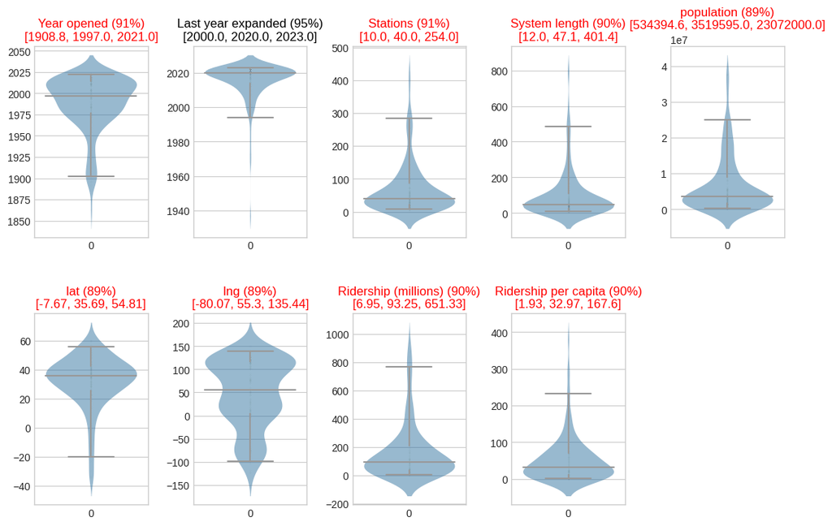

```python
with warnings.catch_warnings():
    box_violin_plot(df, cols_num);
```

Estos gráficos nos ayudan también a identificar valores extremos (outliers). Por ejemplo que el nº de estaciones o la pobación tuviera valores negativos, latitudes fuera de rango [-90,90], etc. Nada de esto sucede si nos fijamos en los boxplots, aunque podemos codificarlo para cerciorarnos:

```python
df[cols_num].describe()
```

|  | Year opened | Last year expanded | Stations | System length | population | lat | lng | Ridership (millions) | Ridership per capita |
| --- | --- | --- | --- | --- | --- | --- | --- | --- | --- |
| count | 205.000000 | 183.000000 | 205.000000 | 205.000000 | 2.050000e+02 | 205.000000 | 205.000000 | 140.000000 | 140.000000 |
| mean | 1988.907317 | 2015.918033 | 69.243902 | 99.689698 | 6.776130e+06 | 31.989243 | 48.288138 | 161.934500 | 52.219741 |
| std | 32.145902 | 10.565799 | 76.443360 | 132.231555 | 7.816394e+06 | 18.127545 | 73.158234 | 196.443906 | 61.779523 |
| min | 1863.000000 | 1937.000000 | 2.000000 | 4.100000 | 3.538400e+04 | -34.599700 | -123.100000 | 0.400000 | 0.049944 |
| 25% | 1977.000000 | 2014.000000 | 21.000000 | 28.000000 | 1.683059e+06 | 25.286700 | 4.500000 | 36.500000 | 11.294210 |
| 50% | 1997.000000 | 2020.000000 | 40.000000 | 47.100000 | 3.519595e+06 | 35.689700 | 55.297200 | 93.250000 | 32.967561 |
| 75% | 2014.000000 | 2022.000000 | 88.000000 | 109.000000 | 8.911000e+06 | 42.318800 | 116.407500 | 209.207500 | 69.845015 |
| max | 2023.000000 | 2023.000000 | 424.000000 | 795.500000 | 3.773200e+07 | 60.170800 | 151.210000 | 935.200000 | 380.850837 |

## Correlaciones

```python
def nor(x):
    range_vals = max(x) - min(x)
    if not range_vals: return x
    return (x - min(x))/range_vals

def plot_corr(df, cols, annotbool=True, figsize=(5, 5)):
    corr = df[cols].corr()*100

    plt.figure(figsize=figsize)
    sns.heatmap(corr, annot=annotbool, mask=np.triu(corr), fmt=".1f", cmap='RdBu', vmin=-100, vmax=100)
    return corr;
```

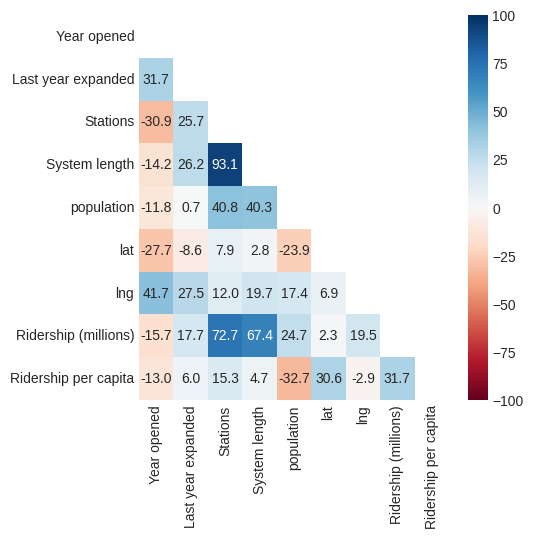

```python
df_norm = copy.deepcopy(df.loc[:,cols_num])

for col in cols_num:
    df_norm[col] = nor(df_norm[col])

corr = plot_corr(df_norm, cols_num);
```

Como los violinplots ya dejaban entrever, el número de estaciones es fuertemente correlativo con la longitud del metro (93.1%).

El número de viajeros (`Ridership (millions)`) se correlaciona con los anteriores dos campos al 73 y 67% respectivamnete.

Estas tres correlaciones son lógicas:

- a mas estaciones mas distancia total
- a mas estaciones (y mayores distancias abarcables) pues mas viajeros se benefician del sistema ferroviario subterráneo

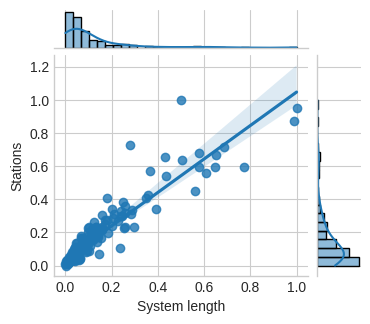

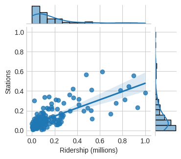

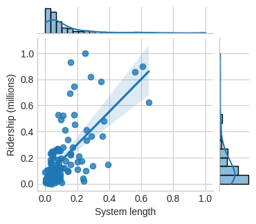

```python
for k in ['System length', 'Ridership (millions)']:
    g = sns.jointplot(data=df_norm, x=k, y='Stations', kind='reg')
    g.fig.set_size_inches((3.5, 3))
g = sns.jointplot(data=df_norm, x='System length', y='Ridership (millions)', kind='reg')
g.fig.set_size_inches((3.5, 3));
```

El resto de variables numérica están poco correlacionadas. A resaltar el 42% entre la longitud geográfica `lng` y el año de inaguración, que como se grafica en siguiente apartado, denota la incipiente construcción de líneas de metro nuevas en China y el lejano oriente en general. A como ciudades grandes requieren mas estaciones y cobertura espacial (y viceversa en pequeñas), es decir, correlaciones superiores al 40% entre `population` y `estations` como entre `population` y `System length`.

Si eliminamos los outliers (aquellos que se alejan mas de 3 desviaciones estándar de la media) las regresiones anteriores (excepto una) no se darán tan fuertes, como se denota al rechequear las correlaciones:

```python
def remove_outliers(col, limit=3):
    mn = np.nanmean(col)
    out = limit * np.nanstd(col)
    mask = (col < (mn - out)) | (col > (mn + out))
    return col[~mask]
```

```python
df_norm_no_outliers = df_norm.copy()
df_norm_no_outliers = df_norm_no_outliers.apply(remove_outliers)
```

Los outliers no se han eliminado, sino reemplazados por NaN:

```python
df_norm.shape[0], df_norm_no_outliers.shape[0]
```

```
(205, 205)
```

```python
df_check_nan_null(df_norm_no_outliers);
```

```
** NA **

Non NaN cols:
 Year opened              2
Last year expanded      26
Stations                 5
System length            6
population               5
lat                      6
Ridership (millions)    70
Ridership per capita    68
dtype: int64


** Blancos **

Non zero cols:
 Series([], dtype: int64)
```

Las correlaciones sin considerar outliers son:

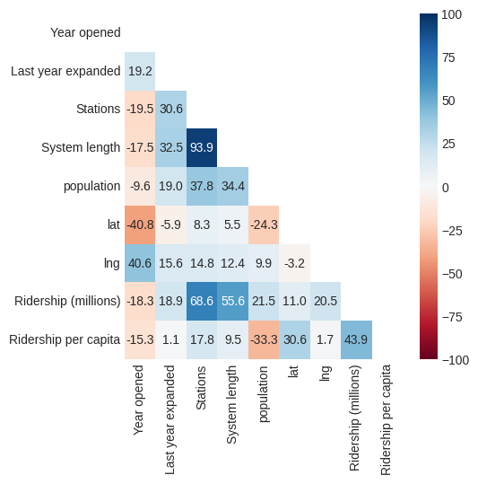

```python
corr_no_outliers = plot_corr(df_norm_no_outliers, cols_num);
```

Lo que reafirma la codependencia kilómetros-estaciones (94%):

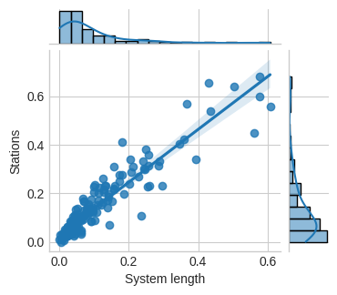

```python
g = sns.jointplot(data=df_norm_no_outliers, x='System length', y='Stations', kind='reg')
g.fig.set_size_inches((3.5, 3));
```

La diferencia entre tabla de correlaciones con y sin outliers es moderada.

```python
corr_diff = corr - corr_no_outliers
corr_diff.describe().loc[['mean', 'min', 'max']].applymap(lambda x: format(x, ".1f"))
```

|  | Year opened | Last year expanded | Stations | System length | population | lat | lng | Ridership (millions) | Ridership per capita |
| --- | --- | --- | --- | --- | --- | --- | --- | --- | --- |
| mean | 2.4 | -0.5 | -1.7 | 1.5 | -0.0 | 1.0 | 3.3 | -0.2 | -1.8 |
| min | -11.4 | -18.3 | -11.4 | -6.3 | -18.3 | -8.8 | -4.6 | -12.1 | -12.1 |
| max | 13.1 | 12.4 | 4.1 | 11.8 | 7.5 | 13.1 | 12.0 | 11.8 | 4.9 |

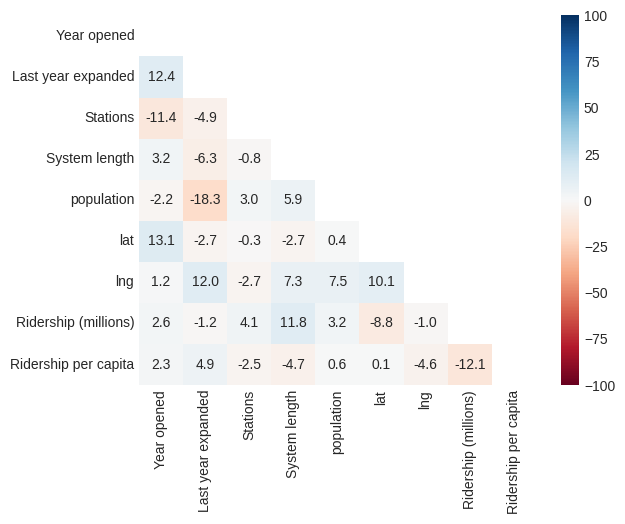

```python
sns.heatmap(corr_diff, annot=True, mask=np.triu(corr), fmt=".1f", cmap='RdBu', vmin=-100, vmax=100);
```

## Regresión lineal

Para aplicar el modelo de regresión lineal se ha de trabajar con datasets sin NaN, pero los outliers pasaron a ser NaN, y con que fuese outlier en un campo ya he de eliminar la tupla entera:

```python
df_norm_no_outliers_no_nan = df_norm_no_outliers.dropna()
```

```python
from sklearn.linear_model import LinearRegression

model = LinearRegression(fit_intercept=True)

y_col = 'System length'
X = df_norm_no_outliers_no_nan.drop(y_col, axis=1).values
y = np.array(df_norm_no_outliers_no_nan[y_col])[:, np.newaxis]

X.shape, y.shape
```

```
((112, 8), (112, 1))
```

Aplico el modelo

```python
model.fit(X, y)
```

```
LinearRegression()
```

Este modelo indica que la aproximación $\hat{y}$ al campo `System length` es tal que:

```python
pd.DataFrame(data=model.coef_, columns=list(set(cols_num).difference(set([y_col]))))
```

|  | lat | Year opened | Stations | population | lng | Ridership (millions) | Last year expanded | Ridership per capita |
| --- | --- | --- | --- | --- | --- | --- | --- | --- |
| 0 | 0.067262 | 0.010513 | 0.794723 | 0.002668 | 0.020939 | -0.01282 | 0.007279 | -0.081639 |

```python
model.intercept_
```

```
array([-0.07242396])
```

```python
import statsmodels.api as sm
results = sm.OLS(y, X).fit()
print(results.summary(),'\n')
# individual results parameters can be accessed
print('Parameters: ', results.params)
print('R2: ', results.rsquared)
```

```
                                 OLS Regression Results
=======================================================================================
Dep. Variable:                      y   R-squared (uncentered):                   0.935
Model:                            OLS   Adj. R-squared (uncentered):              0.930
Method:                 Least Squares   F-statistic:                              187.1
Date:                Fri, 16 Jun 2023   Prob (F-statistic):                    3.96e-58
Time:                        21:20:36   Log-Likelihood:                          227.91
No. Observations:                 112   AIC:                                     -439.8
Df Residuals:                     104   BIC:                                     -418.1
Df Model:                           8
Covariance Type:            nonrobust
==============================================================================
                 coef    std err          t      P>|t|      [0.025      0.975]
------------------------------------------------------------------------------
x1             0.0553      0.022      2.495      0.014       0.011       0.099
x2            -0.0482      0.029     -1.656      0.101      -0.106       0.010
x3             0.8075      0.044     18.402      0.000       0.720       0.895
x4            -0.0063      0.029     -0.221      0.825      -0.063       0.051
x5             0.0076      0.021      0.357      0.722      -0.035       0.050
x6            -0.0088      0.013     -0.668      0.505      -0.035       0.017
x7             0.0053      0.035      0.153      0.879      -0.063       0.074
x8            -0.0888      0.039     -2.293      0.024      -0.166      -0.012
==============================================================================
Omnibus:                       64.171   Durbin-Watson:                   2.037
Prob(Omnibus):                  0.000   Jarque-Bera (JB):              344.509
Skew:                           1.863   Prob(JB):                     1.55e-75
Kurtosis:                      10.742   Cond. No.                         29.3
==============================================================================

Notes:
[1] R² is computed without centering (uncentered) since the model does not contain a constant.
[2] Standard Errors assume that the covariance matrix of the errors is correctly specified.

Parameters:  [ 0.055267   -0.0481955   0.80750771 -0.00634602  0.00760379 -0.00881157
  0.00527578 -0.08876115]
R2:  0.9350200760687406
```

## Estudios diversos

Ciudades con mas de un sistema de metro:

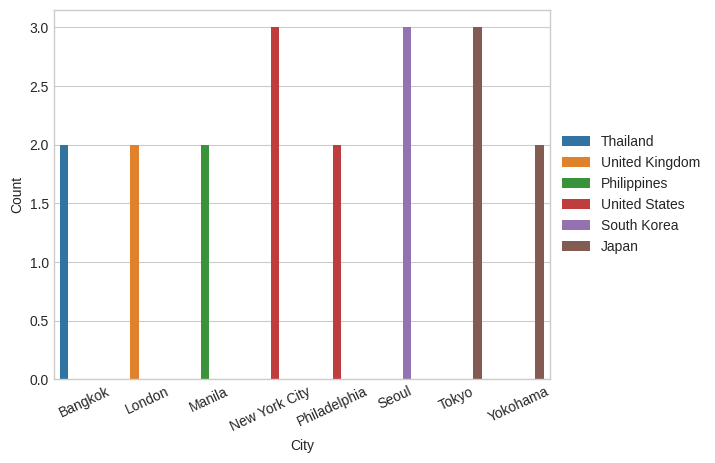

```python
unique_cities = df.groupby(['City', 'country']).size().reset_index(name='Count')
mask_cities = unique_cities['Count'] > 1

ax = sns.barplot(data=unique_cities[mask_cities], x='City', y='Count', hue='country')
ax.legend(loc='center left', bbox_to_anchor=(1.0, 0.5))
plt.xticks(rotation=25);
```

Agrupamos datos de metros de una misma ciudad:

```python
# total number of stations and system length for each city-country pair
city_country_totals = df.groupby(['City', 'country']).agg({'Stations': 'sum',
                                                           'System length': 'sum',
                                                           'Year opened': 'min',
                                                           'Last year expanded': 'max',
                                                           'lat': 'mean',
                                                           'lng': 'mean',
                                                           'Ridership (millions)': 'sum',
                                                           'Ridership per capita': 'sum'}).reset_index()
```

Por ejemlo Nueva York tiene 3 redes de metro, con un total de 458 estaciones:

```python
df[df['City']=="New York City"]
```

|  | City | Name | Year opened | Last year expanded | Stations | System length | country | admin_name | population | lat | lng | Ridership (millions) | Ridership Year | Ridership per capita |
| --- | --- | --- | --- | --- | --- | --- | --- | --- | --- | --- | --- | --- | --- | --- |
| 194 | New York City | New York City Subway | 1904 | 2017.0 | 424 | 399.0 | United States | New York | 18972871.0 | 40.6943 | -73.9249 | NaN | NaN | NaN |
| 195 | New York City | Staten Island Railway | 1925 | 2017.0 | 21 | 22.5 | United States | New York | 18972871.0 | 40.6943 | -73.9249 | 3.8 | 2022 | 0.200286 |
| 196 | New York City | PATH | 1908 | 1937.0 | 13 | 22.2 | United States | New York | 18972871.0 | 40.6943 | -73.9249 | 45.5 | 2022 | 2.398161 |

```python
city_country_totals[city_country_totals['City']=="New York City"]
```

|  | City | country | Stations | System length | Year opened | Last year expanded | lat | lng | Ridership (millions) | Ridership per capita |
| --- | --- | --- | --- | --- | --- | --- | --- | --- | --- | --- |
| 120 | New York City | United States | 458 | 443.7 | 1904 | 2017.0 | 40.6943 | -73.9249 | 49.3 | 2.598447 |

Redes de metro: cuantas se crean y cuando han sido por último expandidas.

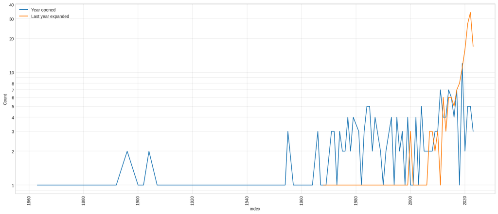

```python
fig, ax = plt.subplots(figsize=(20, 8))
cols = ['Year opened', 'Last year expanded']
for col in cols:
    df_aux = city_country_totals[col].value_counts().reset_index(name='Count')

    l = sns.lineplot(data=df_aux, x='index', y='Count', markers=True, dashes=False,ax=ax,label=col)
    l.set(yscale="log")

plt.xticks(rotation=90)
plt.grid(visible=True, which='both', color='black', linewidth=0.075)

# Customize y-ticks
ax.set_yscale("log")
ax.yaxis.set_major_locator(ticker.LogLocator(base=10, subs=range(1,9)))
ax.yaxis.set_major_formatter(ticker.ScalarFormatter())
```

Cantidad de redes de metro que se han abierto cada año (`Year opened`), pero solo de los 5 países con mas redes. Similar con `Last year expanded`.

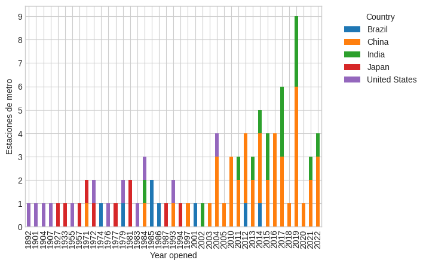

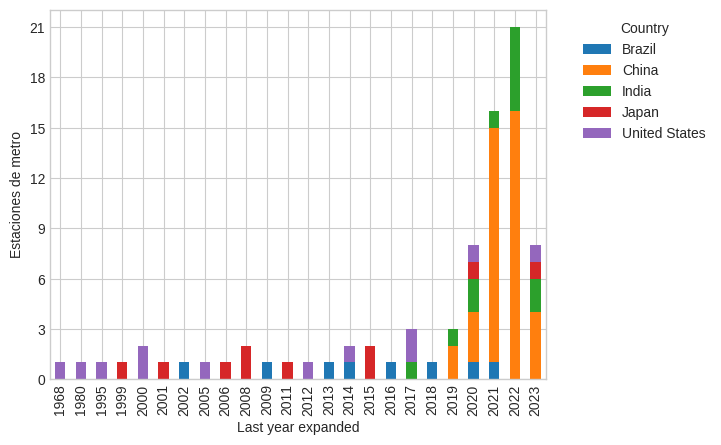

```python
def plot_year(df=city_country_totals, col='Year opened', top_n=5):

    # occurrences of each country
    country_counts = df['country'].value_counts()

    # top 5 countries
    top_countries = country_counts.head(top_n).index

    # filter
    filtered_df = df[df['country'].isin(top_countries)]

    # group the filtered DataFrame
    grouped = filtered_df.groupby([col, 'country']).size().unstack()

    # plot
    ax = grouped.plot(kind='bar', stacked=True)
    ax.yaxis.set_major_locator(ticker.MaxNLocator(integer=True))
    ax.set_xticklabels([int(float(label.get_text()))
                        if float(label.get_text()).is_integer()
                        else label.get_text()
                        for label in ax.get_xticklabels()])
    plt.xlabel(col)
    plt.ylabel('Estaciones de metro')
    plt.legend(title='Country', bbox_to_anchor=(1.05, 1), loc='best')
    plt.plot()

[plot_year(col=k) for k in ['Year opened', 'Last year expanded']];
```

Países con mas estaciones:

```python
def df_count_values(df=city_country_totals, col='Stations', top_n=10, mean=False):
    # stations for each country

    if not mean:
        df = df.groupby('country')[col].sum().reset_index()
    else:
        df = df.groupby('country')[col].mean().reset_index()

    # top 10 countries with the most stations
    top_countries = df.nlargest(top_n, col)

    ax = sns.barplot(data=top_countries, x='country', y=col)
    for container in ax.containers:
        ax.bar_label(container, fmt='%.1f');
    plt.xticks(rotation=25)

    return top_countries;
```

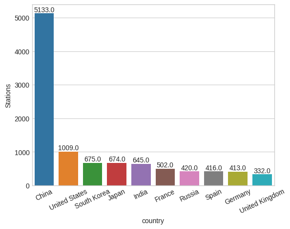

```python
top_countries = df_count_values();
```

En eje de abcisas situamos a la izquierda los países con mas estaciones, y dentro de cada país también ordenamos sus ciudades según el número de estaciones descendetes.

```python
def df_plot_each_city(df=city_country_totals, col='Stations', top_countries=top_countries):

    # Filter the original DataFrame for the selected countries
    filtered_df = df[df['country'].isin(top_countries['country'])]

    # sort cities in each country
    filtered_df = filtered_df.sort_values(by=['country',col], ascending=[True, False])

    # sort countries not unsorting its cities
    boolVar = True
    for k in top_countries['country']:
        df_k = filtered_df[filtered_df['country'] == k]
        if boolVar:
            df_aux = df_k.copy()
            boolVar = False
        else:
            df_aux = pd.concat([df_aux,df_k])

    # bar plot
    plt.figure(figsize=(20, 8))
    ax = sns.barplot(data=df_aux, x='City', y=col, hue='country')

    plt.xlabel('City')
    plt.ylabel(col)
    plt.title(f'Top 10 Countries with the Most {col}')
    plt.legend(title='Country')
    ax.legend(loc='center left', bbox_to_anchor=(0.1, -0.3),fancybox=True, shadow=True, ncol=4)
    plt.xticks(rotation=90);
```

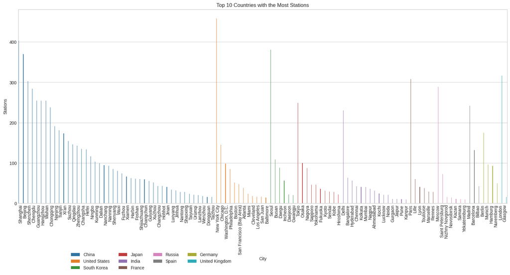

```python
df_plot_each_city()
```

Países con mas kilómetros. Francia es la sexta con mas estaciones, pero la décima en kilómetros:

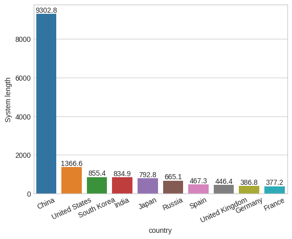

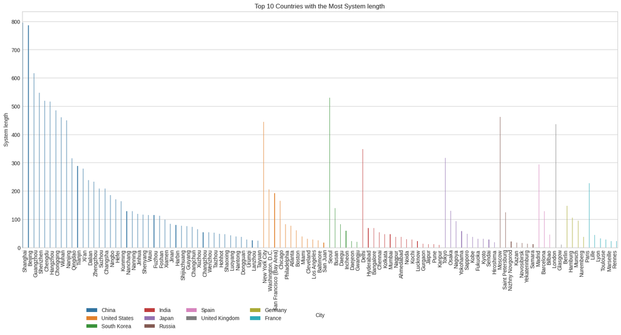

```python
col="System length"
top_countries = df_count_values(col=col);
df_plot_each_city(col=col, top_countries=top_countries);
```

Países con mas viajeros (en el año recogido en la base de datos):

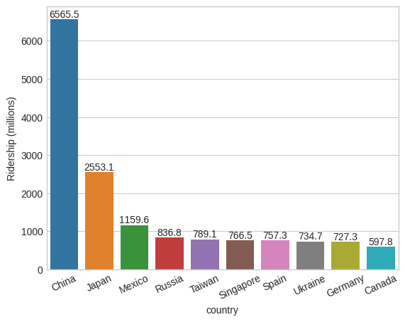

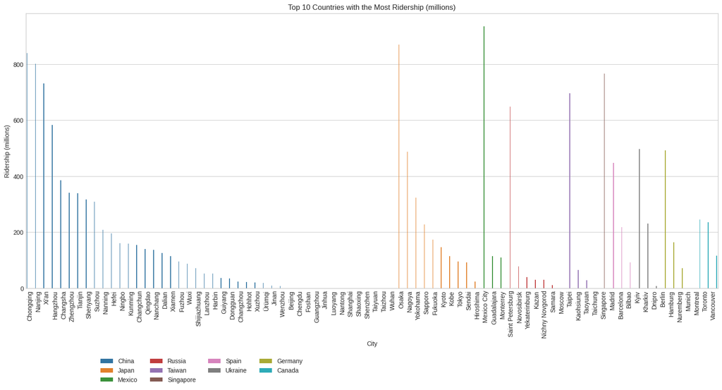

```python
col="Ridership (millions)"
top_countries = df_count_values(col=col);
df_plot_each_city(col=col, top_countries=top_countries);
```

Distribución de pasajeros por latitud, después por longitud. Solo países con mas viajeros. Con estos 2 gráficas y nuestra imaginación podemos comprender como se distribuye la cuantía de viajeros respecto a Greenwich y respecto al ecuador.

Líneas de latitud oscilan entre -90 y +90 grados, las coordenadas de longitud están entre -180 y +180 grados.

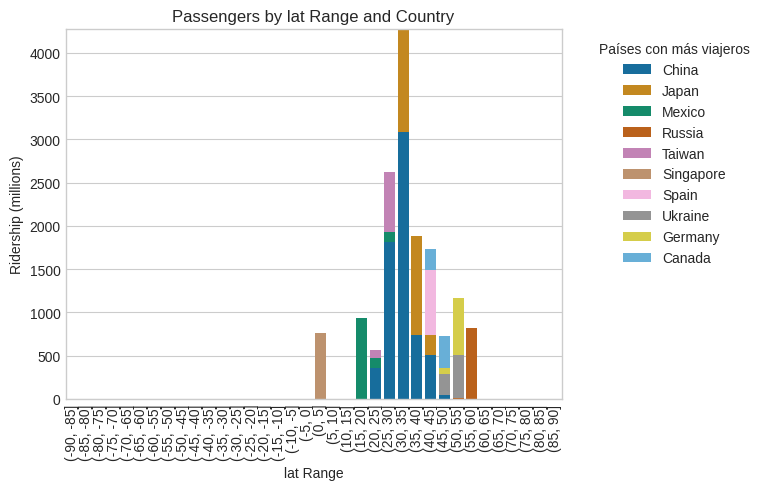

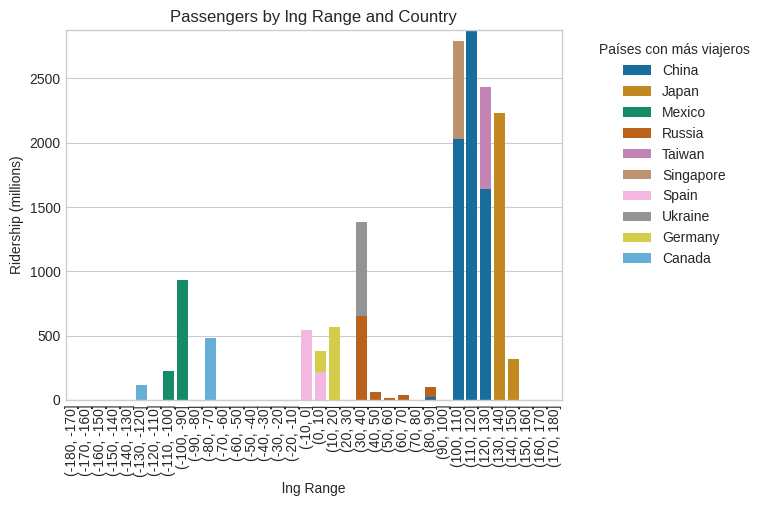

```python
def plot_lat_lng(df=city_country_totals, col='lat', top_countries=top_countries):
    # Define the latitude/longitude ranges for binning
    if col=='lat':
        latlng_ranges = np.arange(-90, 91, 5)
    else:
        latlng_ranges = np.arange(-180, 181, 10)


    # Filter the original DataFrame for the selected countries
    df = df[df['country'].isin(top_countries['country'])]

    # Set up subplots
    fig, ax = plt.subplots()

    # Initialize empty array for stacked heights
    stacked_heights = np.zeros(len(latlng_ranges)-1)

    # Define a color palette for each country
    colors = sns.color_palette('colorblind', len(top_countries))

    # Iterate over countries and plot stacked bar plots
    for i, country in enumerate(top_countries['country']):
        data = df[df['country'] == country][[col, 'Ridership (millions)']]
        data[f'{col}_range'] = pd.cut(data[col], latlng_ranges)  # Bin the latitude values into ranges
        grouped_data = data.groupby(f'{col}_range')['Ridership (millions)'].sum()  # Group by lat_range and sum the ridership
        grouped_data = pd.DataFrame(grouped_data)

        sns.barplot(data=grouped_data, x=grouped_data.index, y='Ridership (millions)',
                    ax=ax, bottom=stacked_heights, label=country, color=colors[i])
        stacked_heights += grouped_data['Ridership (millions)'].values

    # Customize plot
    plt.xlabel(f'{col} Range')
    plt.ylabel('Ridership (millions)')
    plt.title(f'Passengers by {col} Range and Country')
    plt.legend(title='Países con más viajeros', bbox_to_anchor=(1.05, 1), loc='upper left')
    plt.xticks(rotation=90)
    plt.show()


[plot_lat_lng(col=k) for k in ['lat', 'lng']];
```

Países con mas viajeros per capita (en el año recogido en la base de datos).

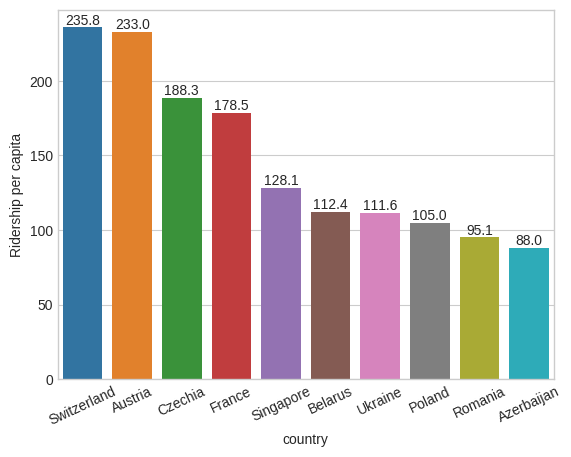

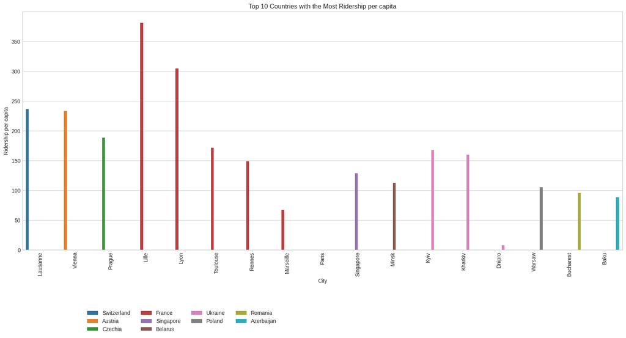

```python
col="Ridership per capita"
top_countries = df_count_values(col=col, mean=True);
df_plot_each_city(col=col, top_countries=top_countries);
```

Ciudades con mas estaciones:

```python
def plot_top_cities(df=df, col='Stations'):
    top_cities = df.groupby(['City', 'country'])[col].sum().nlargest(20).reset_index(name=col)
    ax = sns.barplot(data=top_cities, x='City', y=col, hue='country')
    ax.legend(loc='center left', bbox_to_anchor=(1.0, 0.5))
    plt.xticks(rotation=90);
```

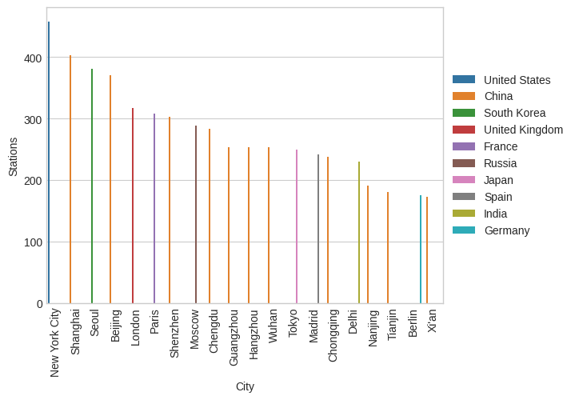

```python
plot_top_cities()
```

Ciudades con mas kilómetros:

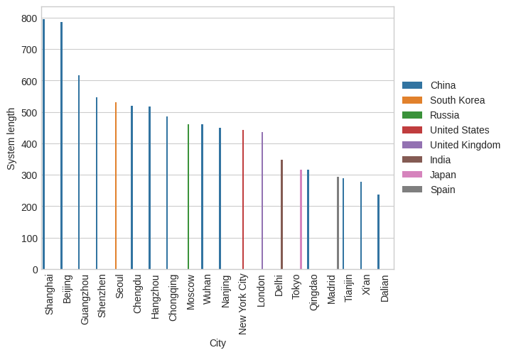

```python
plot_top_cities(col="System length")
```

Ciudades con mas viajeros por año (en el año recogido en la base de datos):

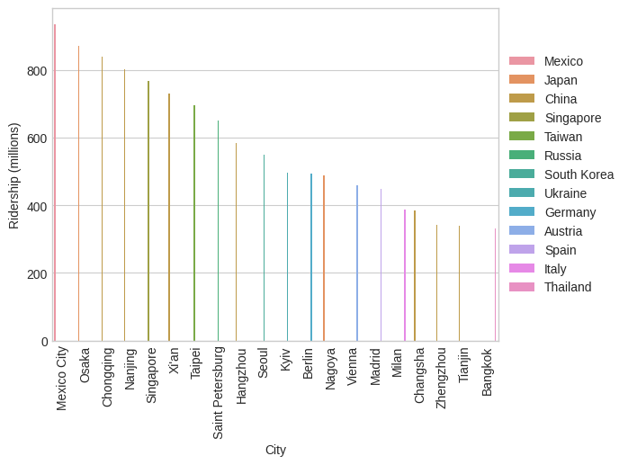

```python
plot_top_cities(col="Ridership (millions)")
```

Ciudades con mas viajeros per capita (en el año recogido en la base de datos).

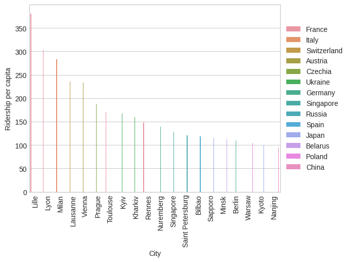

```python
plot_top_cities(col="Ridership per capita")
```